# Guía complementaria · Regresión lineal

Bioestadística · Semana 2 · 2026-II

Autor/a

Javier Rodríguez-Barrios

Fecha de publicación

15 de octubre de 2026

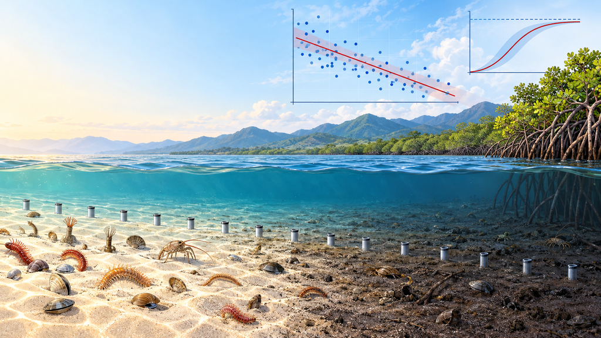

## Propósito de este material

Esta guía complementa el **Taller 3 · Regresión lineal simple y múltiple**. No es necesaria para seguir la sesión: profundiza en temas que no caben en las horas de clase y que conviene tener a mano al diseñar el propio proyecto de grado.

1. **Qué hacer cuando el tamaño de muestra no alcanza**: potencia con el n disponible, efecto mínimo detectable y el caso de la turbidez (secciones 1 a 3).
2. **Cómo repartir las estaciones a lo largo del gradiente**: con el mismo n, la ubicación de las unidades cambia la potencia (sección 4).
3. **Dos herramientas de apoyo**: independencia con Durbin-Watson y selección automática de modelos con `step()` (secciones 5 y 6).

Se recrean los datos del taller con las mismas semillas, así que todos los números coinciden con los de la sesión.

```r
# Librerías requeridas
library(pwr)   # pwr.f2.test()
library(car)   # durbinWatsonTest()

# Tamaño del efecto f² de Cohen (global si R2_A = 0; parcial si se da R2_A)
f2_cohen <- function(R2_AB, R2_A = 0) (R2_AB - R2_A) / (1 - R2_AB)

# pwr.f2.test() devuelve v (gl del error), no n
n_desde_v <- function(v, u) ceiling(v) + u + 1
```

### Los datos del taller

```r
# Manglar: riqueza de peces vs. área del parche (Parte 2 del taller)
set.seed(344)
n <- 20
area_ha <- round(runif(n, 0.4, 60), 1)
log_riq <- 0.60 + 0.31 * log10(area_ha) + rnorm(n, 0, 0.07)
riqueza <- round(10^log_riq)
riqueza[riqueza < 1] <- 1
manglar <- data.frame(sitio = paste0("M", 1:n), area_ha, riqueza)
mod_sp <- lm(log10(riqueza) ~ log10(area_ha), data = manglar)

# Coral: crecimiento vs. temperatura y profundidad (Parte 4 del taller)
set.seed(194)
n <- 32
temperatura <- round(runif(n, 25, 31), 1)
profundidad <- round(runif(n, 2, 25), 1)
crecimiento <- round(-8.70 + 0.40 * temperatura - 0.08 * profundidad + rnorm(n, 0, 0.45), 2)
coral <- data.frame(colonia = paste0("C", 1:n), temperatura, profundidad, crecimiento)
mod_coral <- lm(crecimiento ~ temperatura + profundidad, data = coral)

# Turbidez (Parte 6 del taller)
set.seed(77)
coral$turbidez <- round(runif(n, 1, 12), 1)
mod_full <- lm(crecimiento ~ temperatura + profundidad + turbidez, data = coral)
```

## 1. Potencia con el n disponible

En el taller se calculó cuántas unidades se necesitan **antes** de salir a campo. La pregunta inversa también es útil: con las unidades que ya se tienen, **¿qué probabilidad había de detectar un efecto de cierto tamaño?**

¿Qué potencia tenían los dos ejemplos del taller para un efecto mediano de Cohen (f² = 0.15, R² ≈ 0.13)?

```r
# Manglar: n = 20, u = 1  |  Coral: n = 32, u = 2   (v = n − u − 1)
c(manglar = pwr.f2.test(u = 1, v = 20 - 1 - 1, f2 = 0.15)$power,
  coral   = pwr.f2.test(u = 2, v = 32 - 2 - 1, f2 = 0.15)$power)
```

```
  manglar     coral
0.3745851 0.4450485
```

Con 20 parches, un efecto mediano se detectaría solo en un 37 % de los estudios; con 32 colonias, en un 45 %. En ambos casos, **un efecto de ese tamaño pasaría desapercibido más de la mitad de las veces**. Los efectos del taller se detectaron porque eran grandes (r² = 0.79 en el manglar y R² = 0.72 en el coral), no porque el n fuera holgado.

La curva de potencia muestra cómo crece la potencia con el n para tres tamaños de efecto:

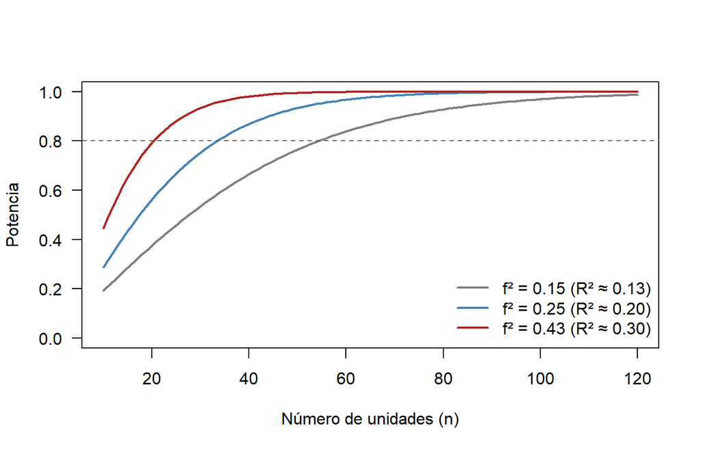

```r
# Potencia en función de n para u = 1
n_grid <- 10:120
pot <- sapply(c(0.15, 0.25, 0.43), function(f2_ef)
  sapply(n_grid, function(nn) pwr.f2.test(u = 1, v = nn - 2, f2 = f2_ef)$power))

matplot(n_grid, pot, type = "l", lty = 1, lwd = 2,
        col = c("gray50", "steelblue", "firebrick"),
        xlab = "Número de unidades (n)", ylab = "Potencia",
        ylim = c(0, 1), las = 1)
abline(h = 0.80, lty = 2, col = "gray40")
legend("bottomright", bty = "n", lwd = 2,
       col = c("gray50", "steelblue", "firebrick"),
       legend = c("f² = 0.15 (R² ≈ 0.13)", "f² = 0.25 (R² ≈ 0.20)", "f² = 0.43 (R² ≈ 0.30)"))
```

La línea punteada marca el 80 %. Con un efecto como el del bentos del taller (R² ≈ 0.30, curva roja) se llega con unas 21 unidades; con un efecto mediano (curva gris), hacen falta 55.

## 2. Efecto mínimo detectable

Si el n ya está fijado (por presupuesto, logística o permisos), se invierte la pregunta: **¿cuál es el efecto más pequeño que el diseño puede detectar con una potencia del 80 %?** En `pwr.f2.test()` basta con dejar `f2` sin valor:

```r
# Se deja f2 sin valor y se fijan u, v y la potencia
mde <- c(manglar = pwr.f2.test(u = 1, v = 18, power = 0.80)$f2,
         coral   = pwr.f2.test(u = 2, v = 29, power = 0.80)$f2)

# Se traduce a R² para interpretarlo
round(rbind(f2 = mde, R2 = mde / (1 + mde)), 2)
```

```
   manglar coral
f2    0.44  0.33
R2    0.31  0.25
```

Con 20 parches solo se detectan, de forma confiable, relaciones con R² ≥ 0.31; con 32 colonias y dos predictores, R² ≥ 0.25. Reportar este valor es la forma honesta de presentar un estudio con n limitado: deja claro qué efectos podía detectar y cuáles no.

## 3. El caso de la turbidez: «no significativo» no es «no hay efecto»

En la Parte 6 del taller, agregar la turbidez no mejoró el modelo (p = 0.48). ¿Significa eso que la turbidez no influye en el crecimiento coralino? Se calcula cuánta potencia tenía esa prueba:

```r
# Aporte parcial de la turbidez sobre temperatura + profundidad
f2_turb <- f2_cohen(R2_AB = summary(mod_full)$r.squared,
                    R2_A  = summary(mod_coral)$r.squared)
f2_turb
```

```
[1] 0.01862735
```

```r
# Potencia con 32 colonias (modelo con 3 predictores: v = 32 − 3 − 1)
pwr.f2.test(u = 1, v = 32 - 3 - 1, f2 = f2_turb)$power
```

```
[1] 0.111555
```

```r
# Colonias necesarias para llegar a 80 %
n_desde_v(pwr.f2.test(u = 1, f2 = f2_turb, power = 0.80)$v, u = 1)
```

```
[1] 424
```

La prueba tenía alrededor de **11 % de potencia**, y detectar un aporte de ese tamaño exigiría unas **424 colonias**. Con 32 colonias, no detectar el efecto era el resultado esperable aunque el efecto existiera.

**NotaEl mismo f² sale de la tabla de `anova()`**

Para un predictor añadido, el f² parcial es F × u / v de la comparación de modelos anidados:

```r
# F de la comparación de modelos anidados (Parte 6 del taller)
F_turb <- anova(mod_coral, mod_full)$F[2]
F_turb * 1 / mod_full$df.residual
```

```
[1] 0.01862735
```

**La alternativa: reformular como estimación.** En lugar de un «sí o no», se reporta el coeficiente con su intervalo de confianza:

```r
# IC 95 % del coeficiente de la turbidez
round(confint(mod_full)["turbidez", ], 3)
```

```
 2.5 % 97.5 %
-0.035  0.072
```

El intervalo (−0.035 a 0.072 mm/año por NTU) incluye el 0, pero también efectos no despreciables: a lo largo del rango muestreado (1 a 12 NTU), una pendiente de 0.07 equivaldría a casi 0.8 mm/año de diferencia en el crecimiento. Los datos son compatibles tanto con un efecto nulo como con uno pequeño en cualquier dirección. Esa es la conclusión que se puede defender con 32 colonias.

## 4. Cómo repartir las estaciones a lo largo del gradiente

### 4.1 La idea

La incertidumbre de la pendiente es

$$Var(b_1) = \frac{\sigma^2}{\sum (x_i - \bar{x})^2}$$

- **σ** es la dispersión natural de Y alrededor de la recta (el ruido): todo lo que X no explica.
- **Σ(xᵢ − x̄)²** mide cuánto se separan los valores de X de su media.

Cuanto más se separen los valores de X, más pequeña es la incertidumbre de la pendiente y más fácil es detectarla. Esto **no depende de tener más unidades, sino de dónde se ubican**. Es una palanca de diseño propia de la regresión (RA1).

**El escenario.** Se retoma el bentos de fondos blandos de la Parte 7 del taller: la diversidad funcional (FD) disminuye 0.10 unidades por cada punto porcentual de materia orgánica (MO), y la dispersión natural alrededor de la recta es σ = 0.42. Se comparan tres formas de ubicar las **mismas 20 estaciones** a lo largo del gradiente de MO:

```r
# Tres formas de repartir 20 estaciones a lo largo de la MO (%)
disenos <- list(
  parejo   = seq(1, 10, length.out = 20),
  estrecho = seq(4, 7,  length.out = 20),
  extremos = rep(c(1, 10), each = 10))

# Separación de X y error estándar esperado de la pendiente (σ = 0.42)
sxx <- sapply(disenos, function(x) sum((x - mean(x))^2))
round(rbind(suma_cuadrados_X = sxx,
            error_estandar_b1 = 0.42 / sqrt(sxx)), 3)
```

```
                   parejo estrecho extremos
suma_cuadrados_X  149.211   16.579  405.000
error_estandar_b1   0.034    0.103    0.021
```

### 4.2 Un estudio de cada diseño

Antes de calcular la potencia, conviene ver cómo luce **un** estudio simulado con cada diseño. La relación verdadera (línea gris punteada) es la misma en los tres:

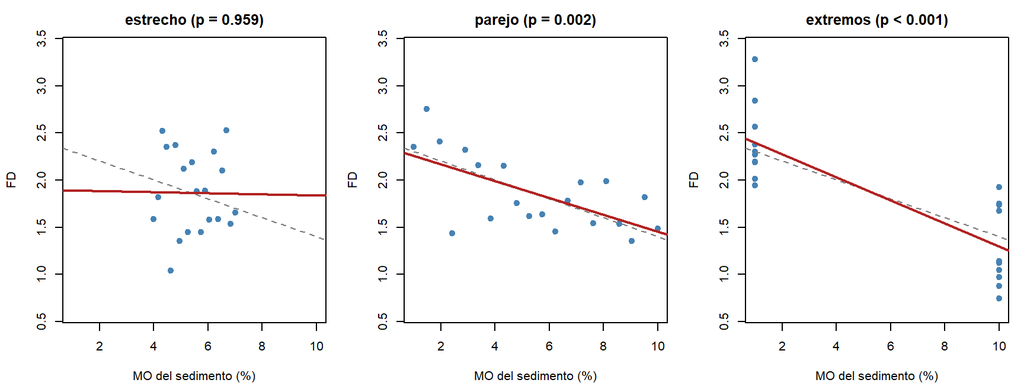

```r
# Un estudio simulado por diseño
set.seed(52)
par(mfrow = c(1, 3), mar = c(4.2, 4.2, 2.5, 1))
for (d in c("estrecho", "parejo", "extremos")) {
  x <- disenos[[d]]
  y <- 2.4 - 0.10 * x + rnorm(length(x), 0, 0.42)
  m <- lm(y ~ x)
  pv <- summary(m)$coefficients[2, 4]
  plot(x, y, pch = 19, col = "steelblue", xlim = c(1, 10), ylim = c(0.6, 3.4),
       xlab = "MO del sedimento (%)", ylab = "FD",
       main = paste0(d, ifelse(pv < 0.001, " (p < 0.001)", sprintf(" (p = %.3f)", pv))))
  abline(a = 2.4, b = -0.10, lty = 2, col = "gray50")
  abline(m, col = "firebrick", lwd = 2)
}
```

```r
par(mfrow = c(1, 1))
```

En el rango estrecho, la FD verdadera solo baja 0.3 unidades entre 4 y 7 % de MO: menos que el ruido (σ = 0.42). En este estudio, la recta ajustada (roja) quedó casi plana y la pendiente no fue significativa, aunque la relación verdadera existe. En el rango parejo, la caída verdadera es de 0.9 unidades, más del doble del ruido, y la tendencia se ve con claridad.

### 4.3 La potencia, por simulación

Un estudio aislado puede salir bien o mal por azar. La potencia es la proporción de estudios que detectan la pendiente cuando se repite el muestreo muchas veces:

```r
# Potencia por simulación para una pendiente concreta
pot_pendiente <- function(x, b1, sigma, nsim = 5000) {
  mean(replicate(nsim, {
    y <- 2.4 + b1 * x + rnorm(length(x), 0, sigma)
    summary(lm(y ~ x))$coefficients[2, 4] < 0.05
  }))
}

# Reproducibilidad
set.seed(2610)

# Misma pendiente (−0.10 FD por % de MO) y misma σ (0.42)
round(sapply(disenos, pot_pendiente, b1 = -0.10, sigma = 0.42), 2)
```

```
  parejo estrecho extremos
    0.79     0.15     0.99
```

Con las mismas 20 estaciones, la potencia pasa de **15 %** (rango estrecho) a **79 %** (parejo) y a **99 %** (solo extremos). Para llegar al 80 % con el rango estrecho harían falta unas 185 estaciones.

### 4.4 El R² cambia; la pendiente no

La pendiente y σ son las mismas en los tres diseños, pero el R² esperado no lo es, porque depende de cuánto varía X en la muestra:

```r
# R² esperado = varianza explicada / varianza total
r2_esperado <- sapply(disenos, function(x) {
  vx <- mean((x - mean(x))^2)
  (0.10^2 * vx) / (0.10^2 * vx + 0.42^2)
})
round(r2_esperado, 2)
```

```
  parejo estrecho extremos
    0.30     0.04     0.53
```

El R² describe la muestra, incluido el rango de X que se eligió; **la pendiente es la propiedad biológica que se busca estimar**. Es otra razón para no comparar R² entre estudios que cubrieron rangos distintos del gradiente.

### 4.5 La trampa de los extremos

Ubicar todas las estaciones en los dos extremos da la máxima potencia, pero **sin puntos intermedios no se puede saber si la relación es una recta**. Se simula una relación con umbral: la FD cae rápido hasta 4 % de MO y luego se estabiliza.

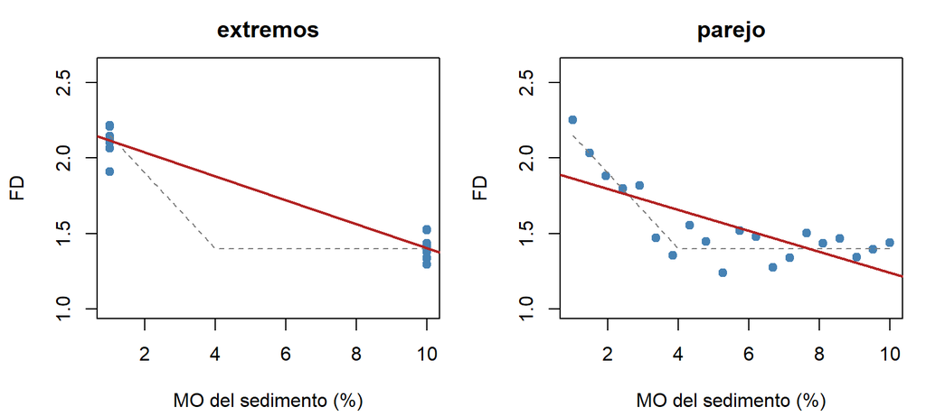

```r
# Relación verdadera con umbral (no lineal)
fd_umbral <- function(mo) 2.4 - 0.25 * pmin(mo, 4)

set.seed(8)
par(mfrow = c(1, 2), mar = c(4.2, 4.2, 2.5, 1))
for (d in c("extremos", "parejo")) {
  x <- disenos[[d]]
  y <- fd_umbral(x) + rnorm(length(x), 0, 0.08)
  plot(x, y, pch = 19, col = "steelblue", xlim = c(1, 10), ylim = c(1, 2.6),
       xlab = "MO del sedimento (%)", ylab = "FD", main = d)
  curve(fd_umbral(x), add = TRUE, lty = 2, col = "gray50")
  abline(lm(y ~ x), col = "firebrick", lwd = 2)
}
```

```r
par(mfrow = c(1, 1))
```

Con solo extremos, la recta (roja) parece un ajuste aceptable y no hay forma de ver que la relación real (gris) tiene un umbral. Con el diseño parejo, los puntos intermedios muestran que la FD deja de bajar a partir de 4 % de MO, y la recta deja de ser un buen resumen. Es la misma lección del parche M15 del taller: **muestrear el gradiente de forma pareja, en la escala en que se va a analizar**.

**TipEn campo**

Antes de escoger las estaciones, conviene conocer el gradiente disponible (por ejemplo, con un mapa de MO del sedimento o un muestreo exploratorio) y seleccionarlas para cubrirlo de forma pareja, en lugar de ubicarlas al azar o por comodidad. Si se sospecha un umbral, conviene densificar el muestreo en la zona donde podría estar.

## 5. Independencia de los residuos: Durbin-Watson

En el taller, la independencia se asegura **desde el diseño**. El estadístico de Durbin-Watson puede complementarlo cuando las observaciones tienen un orden espacial o temporal:

```r
# Independencia de los residuos del modelo del manglar
durbinWatsonTest(mod_sp)
```

```
 lag Autocorrelation D-W Statistic p-value
   1     -0.06045647      2.107866   0.746
 Alternative hypothesis: rho != 0
```

**Nota**

Durbin-Watson evalúa la autocorrelación **según el orden de las filas**. En el manglar, los parches están numerados sin un orden espacial o temporal, así que la prueba dice poco sobre la dependencia real. Si los parches se hubieran registrado a lo largo de la costa, ordenar las filas en esa secuencia sí permitiría evaluar si parches vecinos se parecen entre sí.

## 6. Selección automática de modelos con `step()`

En la Parte 6 del taller se compararon los modelos candidatos con AIC y con `anova()`. `step()` automatiza esa búsqueda por eliminación hacia atrás:

```r
# Selección por eliminación hacia atrás, desde el modelo con turbidez
mod_step <- step(mod_full, direction = "backward", trace = 1)
```

```
Start:  AIC=-47.16
crecimiento ~ temperatura + profundidad + turbidez

              Df Sum of Sq     RSS     AIC
- turbidez     1    0.1063  5.8152 -48.568
<none>                      5.7088 -47.159
- profundidad  1    6.8826 12.5914 -23.847
- temperatura  1   12.5233 18.2321 -12.002

Step:  AIC=-48.57
crecimiento ~ temperatura + profundidad

              Df Sum of Sq     RSS     AIC
<none>                      5.8152 -48.568
- profundidad  1    6.8898 12.7050 -25.560
- temperatura  1   12.4624 18.2775 -13.922
```

```r
# Modelo seleccionado
formula(mod_step)
```

```
crecimiento ~ temperatura + profundidad
```

**Nota**

- Los valores de AIC que imprime `step()` no coinciden con los de `AIC()`, porque `step()` usa `extractAIC()`, que omite una constante. Las **diferencias** entre modelos y el orden resultante son los mismos.
- `step()` solo compara los modelos que se le entregan. Debe aplicarse a un conjunto de candidatos con sentido biológico, no a «todas las variables disponibles». **AIC no indica si un modelo es verdadero**, solo cuál es el más parsimonioso entre los comparados.

## 7. La misma cuenta sin paquetes (opcional)

`pwr.f2.test()` usa la distribución F no central, con parámetro de no centralidad f² · n. Se puede comprobar en R base:

```r
# Potencia del contraste F con n unidades, u predictores y tamaño del efecto f²
pot_F <- function(n, u, f2_ef, alfa = 0.05) {
  v <- n - u - 1
  1 - pf(qf(1 - alfa, u, v), u, v, ncp = f2_ef * n)
}

# Bentos del taller: n = 21, u = 1, R² esperado 0.30
pot_F(21, u = 1, f2_ef = f2_cohen(0.30))
```

```
[1] 0.8120654
```

`pwr.r.test(r = sqrt(0.30), power = 0.80)` da un n algo mayor (≈ 24), porque trata X como aleatoria (correlación) y usa una aproximación. Para planear una regresión, en la que X se elige por diseño, se usa `pwr.f2.test()`.

## Para discutir

1. Un estudio con 15 estaciones no encontró relación entre la riqueza de macroalgas y la temperatura (p = 0.21). ¿Qué cálculo haría antes de concluir que la temperatura no influye?
2. En el propio proyecto, ¿qué R² mínimo tendría relevancia biológica? Con el n que se puede costear, ¿es detectable?
3. ¿Por qué no tiene sentido calcular la potencia con el r² que salió del propio análisis?
4. Si el gradiente de MO accesible en la zona de estudio va de 3 a 6 %, ¿qué opciones de diseño quedan para mejorar la potencia?
5. ¿Cuándo valdría la pena sacrificar potencia (no usar solo extremos) para poder evaluar la forma de la relación?

## Referencias

- Champely, S. (2020). *pwr: Basic Functions for Power Analysis* (paquete de R). https://CRAN.R-project.org/package=pwr
- Cohen, J. (1988). *Statistical Power Analysis for the Behavioral Sciences* (2nd ed.). Lawrence Erlbaum.
- Fox, J., & Weisberg, S. (2019). *An R Companion to Applied Regression* (3rd ed.). Sage. — Paquete `car`.
- Logan, M. (2011). *Biostatistical Design and Analysis Using R*. Wiley-Blackwell.
- Quinn, G. P., & Keough, M. J. (2024). *Experimental Design and Data Analysis for Biologists* (2nd ed.). Cambridge University Press.

**Nota**

Los ejemplos y datos de esta guía son de elaboración propia para el curso; no reproducen ejercicios ni código de las fuentes citadas.